# Assignment

1: importing required files.

```python
import numpy as np
import pandas as pd
import seaborn as sns
import matplotlib.pyplot as plt
sns.set(color_codes=True)
from scipy.stats import skew,ttest_ind
from statsmodels.stats.proportion import proportions_ztest
```

```python
insurance=pd.read_csv("insurance.csv")
```

2: displaying the data as dataframe

```python
insurance.head()
```

|  | age | sex | bmi | children | smoker | region | charges |
| --- | --- | --- | --- | --- | --- | --- | --- |
| 0 | 19 | female | 27.900 | 0 | yes | southwest | 16884.92400 |
| 1 | 18 | male | 33.770 | 1 | no | southeast | 1725.55230 |
| 2 | 28 | male | 33.000 | 3 | no | southeast | 4449.46200 |
| 3 | 33 | male | 22.705 | 0 | no | northwest | 21984.47061 |
| 4 | 32 | male | 28.880 | 0 | no | northwest | 3866.85520 |

```python
insurance['children']=insurance['children'].astype(str)
# This conversion was done as children is considered as categorical in later part of question.
```

3a. shape of the data

```python
print("The shape of data is ",insurance.shape)
```

```
The shape of data is  (1338, 7)
```

3b. Data type of each attribute

```python
print("The data type of each attribute is as follows")
print(insurance.info())
```

```
The data type of each attribute is as follows
<class 'pandas.core.frame.DataFrame'>
RangeIndex: 1338 entries, 0 to 1337
Data columns (total 7 columns):
age         1338 non-null int64
sex         1338 non-null object
bmi         1338 non-null float64
children    1338 non-null object
smoker      1338 non-null object
region      1338 non-null object
charges     1338 non-null float64
dtypes: float64(2), int64(1), object(4)
memory usage: 73.3+ KB
None
```

3c. Checking for missing values

```python
insurance.isna()
```

|  | age | sex | bmi | children | smoker | region | charges |
| --- | --- | --- | --- | --- | --- | --- | --- |
| 0 | False | False | False | False | False | False | False |
| 1 | False | False | False | False | False | False | False |
| 2 | False | False | False | False | False | False | False |
| 3 | False | False | False | False | False | False | False |
| 4 | False | False | False | False | False | False | False |
| ... | ... | ... | ... | ... | ... | ... | ... |
| 1333 | False | False | False | False | False | False | False |
| 1334 | False | False | False | False | False | False | False |
| 1335 | False | False | False | False | False | False | False |
| 1336 | False | False | False | False | False | False | False |
| 1337 | False | False | False | False | False | False | False |

1338 rows × 7 columns

Ans 3c. In the above table everthing is false and in answer of 3b we see that the total entries is equal to each column entries . This indicates absence of null values.

3d. 5 point summary of numerical attributes

```python
print("The 5 point summary that is the minimun,25%,50%,75%,maximum of numerical attributes is as follows")
insurance.describe()
```

```
The 5 point summary that is the minimun,25%,50%,75%,maximum of numerical attributes is as follows
```

|  | age | bmi | charges |
| --- | --- | --- | --- |
| count | 1338.000000 | 1338.000000 | 1338.000000 |
| mean | 39.207025 | 30.663397 | 13270.422265 |
| std | 14.049960 | 6.098187 | 12110.011237 |
| min | 18.000000 | 15.960000 | 1121.873900 |
| 25% | 27.000000 | 26.296250 | 4740.287150 |
| 50% | 39.000000 | 30.400000 | 9382.033000 |
| 75% | 51.000000 | 34.693750 | 16639.912515 |
| max | 64.000000 | 53.130000 | 63770.428010 |

3e. DISTRIBUTION OF NUMERICAL ATTRIBUTES

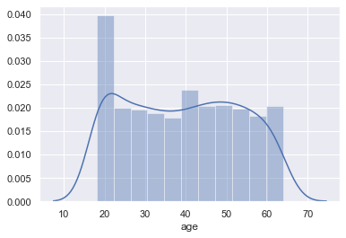

```python
sns.distplot(insurance["age"])
```

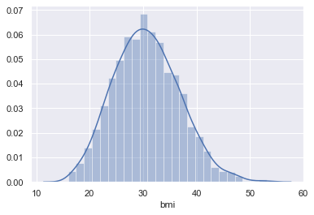

```python
sns.distplot(insurance["bmi"])
```

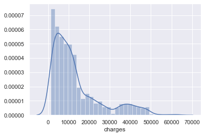

```python
sns.distplot(insurance["charges"])
```

3f: Measuring of skewness of bmi, age and charges columns

```
skewness of age =  0.05567251565299186
```

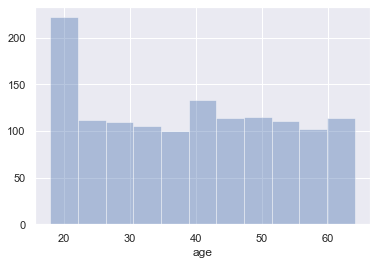

```python
print("skewness of age = ",insurance['age'].skew())
sns.distplot(insurance["age"],kde=False)
```

```
Skewness of bmi =  0.2840471105987448
```

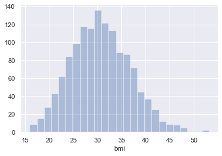

```python
print("Skewness of bmi = ",insurance['bmi'].skew())
sns.distplot(insurance["bmi"],kde=False)
```

```
Skewness of charges =  1.5158796580240388
```

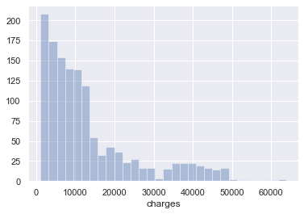

```python
print("Skewness of charges = ",insurance['charges'].skew())
sns.distplot(insurance["charges"],kde=False)
```

3g: Checking the presence of outliers in bmi, age and charges columns

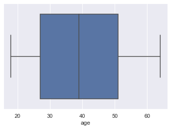

```python
sns.boxplot(insurance["age"])
```

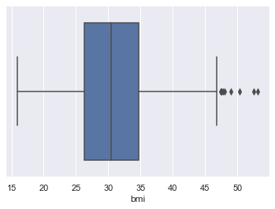

```python
sns.boxplot(insurance["bmi"])
```

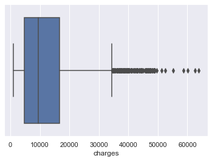

```python
sns.boxplot(insurance["charges"])
```

Thus presence of outliers is seen in bmi and charge. There is no outlier present in age.

3h: Distribution of categorical columns

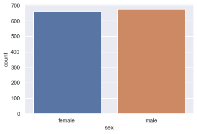

```python
sns.countplot(insurance["sex"])
```

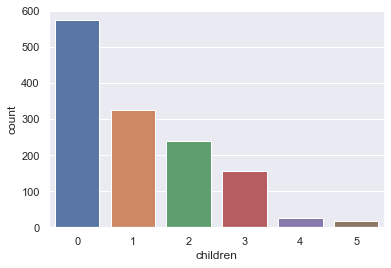

```python
sns.countplot(insurance["children"])
```

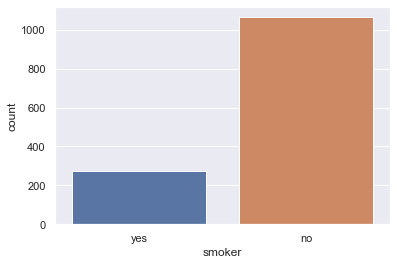

```python
sns.countplot(insurance["smoker"])
```

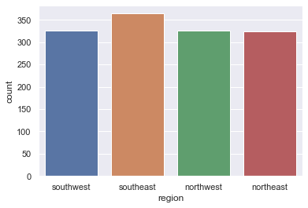

```python
sns.countplot(insurance["region"])
```

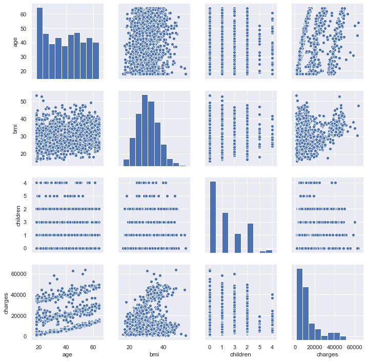

```python
sns.pairplot(insurance[["age","sex","bmi","children","smoker","region","charges"]])
```

4: Answering the following questions with statistical evidence

a. Do charges of people who smoke differ significantly from the people who don't?

b. Does bmi of males differ significantly from that of females?

c. Is the proportion of smokers significantly different in different genders?

d. Is the distribution of bmi across women with no children, one child and two children, the same?

Ans 4a: The following is the hypothesis.

[output not shown]

```python
a=insurance[insurance['smoker']=='yes'].charges
b=insurance[insurance['smoker']=='no'].charges
a_mean=np.mean(a)
b_mean=np.mean(b)
print("Average charge for smoker = ",a_mean," Average charge for non-smoker = ",b_mean)
```

```
Average charge for smoker =  32050.23183153285  Average charge for non-smoker =  8434.268297856199
```

```python
t_statistic, p_value = ttest_ind(a , b)
print("t statistic = ",t_statistic," p value = ", p_value)
if p_value<0.05:
    print("The p value of",p_value,"is significant. Hence reject null hypothesis")
else:
    print("The p value of",p_value,"is not significant. Hence accept null hypothesis")
```

```
t statistic =  46.664921172723716  p value =  8.271435842177219e-283
The p value of 8.271435842177219e-283 is significant. Hence reject null hypothesis
```

4b: The following is the hyposthesis:

[output not shown]

```python
male_group = insurance[insurance['sex']=='male'].bmi
female_group= insurance[insurance['sex']=='female'].bmi
t_statistic, p_value1 = ttest_ind(male_group,female_group)
print("t statistic =",t_statistic," p value =", p_value1)
if p_value1<0.05:
    print("The p value of",p_value1,"is significant. Hence reject null hypothesis")
else:
    print("The p value of",p_value1,"is not significant. Hence accept null hypothesis")
```

```
t statistic = 1.696752635752224  p value = 0.08997637178984932
The p value of 0.08997637178984932 is not significant. Hence accept null hypothesis
```

4c: The following is the hypothesis:

```
Null hypothesis = The proportion of male smokers is eqaul to the female smokers.

Alternate hypothesis = The proportion of male smokers is not equal to female smokers.

For the hypothesis testing we use z-test method
```

```python
female_smokers = insurance[insurance['sex'] == 'female'].smoker.value_counts()[1]
male_smokers = insurance[insurance['sex'] == 'male'].smoker.value_counts()[1]
females = insurance.sex.value_counts()[1]
males = insurance.sex.value_counts()[0]
```

```python
stat, pvalue_1 = proportions_ztest([female_smokers, male_smokers] , [females, males])
print("The stat value = ",stat," P value = ",pvalue_1)
if pvalue_1<0.05:
    print("The p value of",pvalue_1,"is significant. Hence reject null hypothesis")
else:
    print("The p value of",pvalue_1,"is not significant. Hence accept null hypothesis")
```

```
The stat value =  -2.7867402154855503  P value =  0.005324114164320532
The p value of 0.005324114164320532 is significant. Hence reject null hypothesis
```

4d: The following is the hypothesis:

```
Null hypothesis = The mean of bmi of females with different number of children are equal.

Alternate hypothesis = The mean of bmi of females with different number of children are not same.

Since we have to analysis multiple means. We use ANOVA test.
```

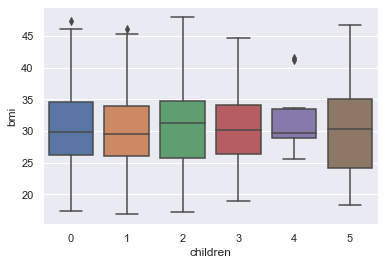

```python
data_2= insurance[insurance['sex']=='female'][['bmi','children']]
sns.boxplot(data_2["children"],data_2["bmi"])
```

```python
import statsmodels.api         as     sm
from   statsmodels.formula.api import ols

mod = ols('bmi ~ children', data = data_2).fit()
aov_table = sm.stats.anova_lm(mod, typ=2)
print(aov_table)
```

```
                sum_sq     df         F    PR(>F)
children     53.274335    5.0  0.289914  0.918623
Residual  24109.180862  656.0       NaN       NaN
```

Here we see that the p value is greater than .05 at choosen level of significanceat 5%.

Thus statistically we accept the null hypothesis.

INFERENCES:

4a: It is seen that there is a significant difference for charge smoker and non smoker. The smokers paid more than non.smokers on average.

4b: It seen using statistical evidence that the difference in bmi of male from female is not significant.

4c: It seen that there is a significant difference in proportion of male to female smokers.